# Correlation and Regression

Alan T. Arnholt

Last updated: February 14, 2023 at 12:35:30 PM

# 1 Correlation

## 1.1 Some Data

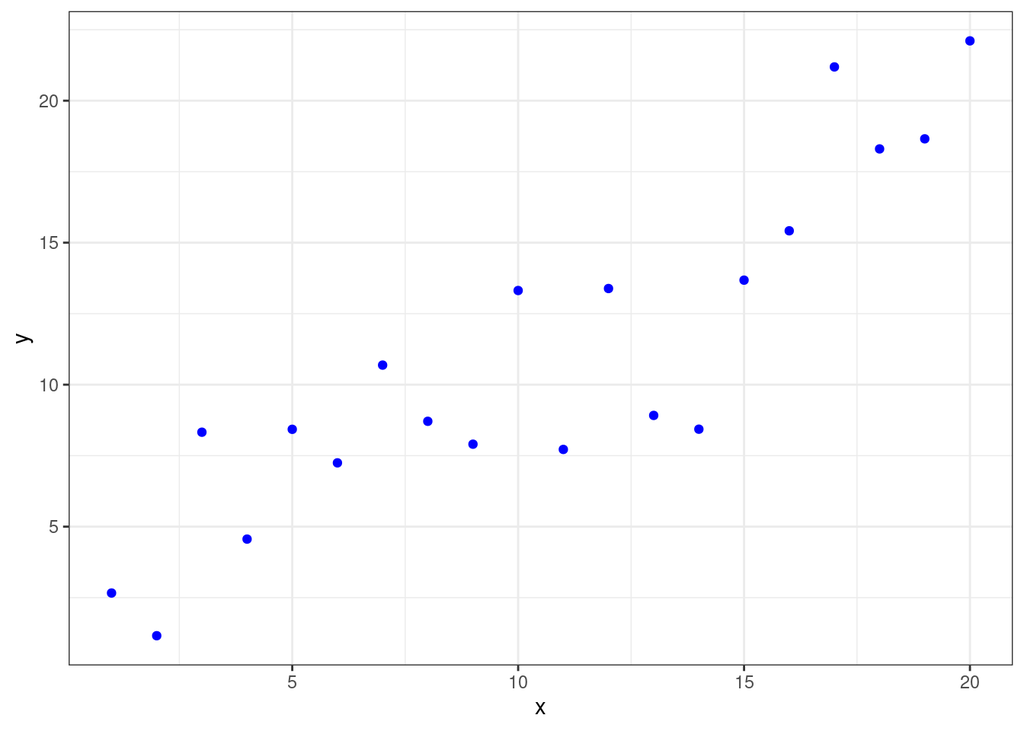

```r
set.seed(13)
x <- 1:20
y <- x + rnorm(20, 0, 3)
DFP <- data.frame(x = x, y = y)
y <- x + rnorm(20, 0, 3)
DFN <- data.frame(x = -x, y = y)
rm(x, y)
library(tidyverse)
ggplot(data = DFP, aes(x = x, y = y)) +
  geom_point(color = "blue") +
  theme_bw() -> p1
p1
```

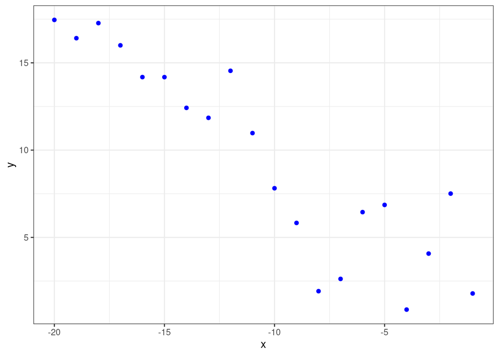

```r
ggplot(data = DFN, aes(x = x, y = y)) +
  geom_point(color = "blue") +
  theme_bw() -> p2
p2
```

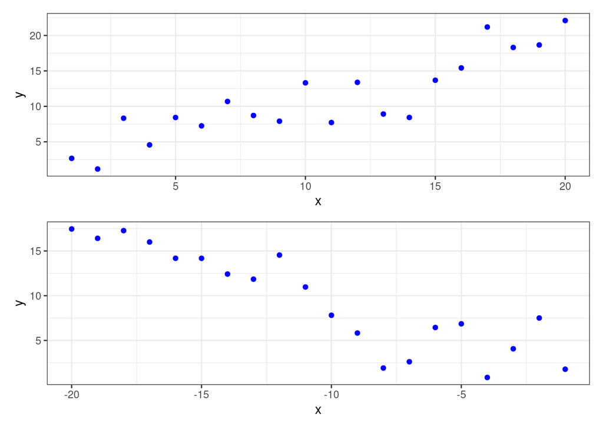

```r
library(patchwork)
p1/p2
```

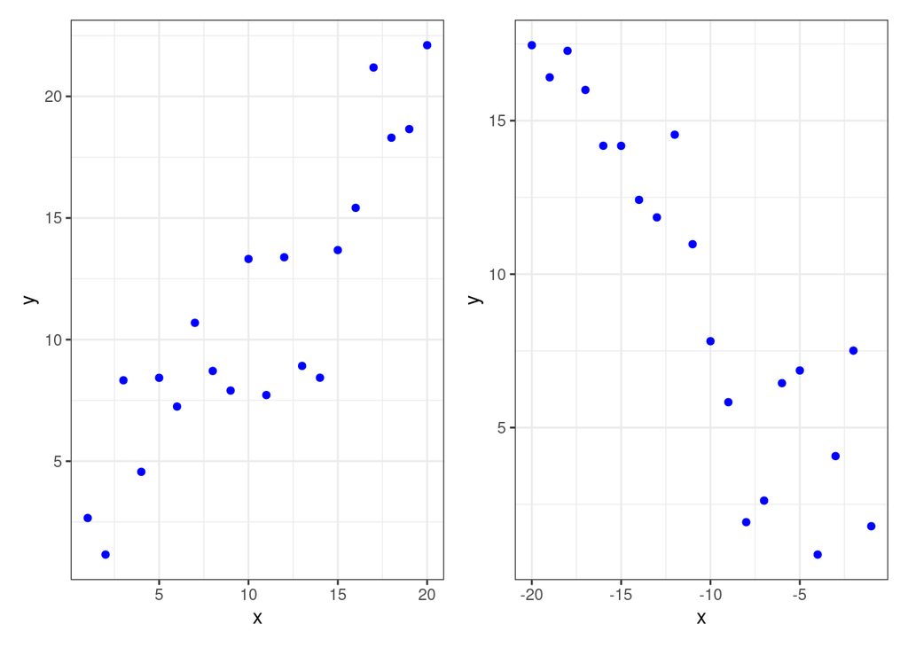

```r
p1 + p2
```

$$r = \dfrac{1}{n-1}\sum_{i=1}^n\frac{(x - \bar{x})}{s_x}\frac{(y - \bar{y})}{s_y}$$

```r
DFP %>%
  mutate(x_xbar = x - mean(x), y_ybar = y - mean(y), zx = x_xbar/sd(x), zy = y_ybar/sd(y), zxzy = zx*zy) -> steps
steps
```

```
    x         y x_xbar     y_ybar          zx          zy        zxzy
1   1  2.662981   -9.5 -8.3774516 -1.60579308 -1.43325625  2.30151297
2   2  1.159184   -8.5 -9.8812482 -1.43676223 -1.69053329  2.42889438
3   3  8.325490   -7.5 -2.7149423 -1.26773138 -0.46448588  0.58884333
4   4  4.561960   -6.5 -6.4784720 -1.09870053 -1.10836935  1.21776599
5   5  8.427578   -5.5 -2.6128540 -0.92966968 -0.44702010  0.41558104
6   6  7.246578   -4.5 -3.7938540 -0.76063883 -0.64907149  0.49370898
7   7 10.688520   -3.5 -0.3519127 -0.59160798 -0.06020699  0.03561893
8   8  8.710039   -2.5 -2.3303934 -0.42257713 -0.39869534  0.16847953
9   9  7.903852   -1.5 -3.1365807 -0.25354628 -0.53662189  0.13605848
10 10 13.315433   -0.5  2.2750004 -0.08451543  0.38921843 -0.03289496
11 11  7.719218    0.5 -3.3212143  0.08451543 -0.56820993 -0.04802250
12 12 13.385613    1.5  2.3451803  0.25354628  0.40122516  0.10172915
13 13  8.917046    2.5 -2.1233860  0.42257713 -0.36327948 -0.15351360
14 14  8.431919    3.5 -2.6085139  0.59160798 -0.44627758 -0.26402137
15 15 13.680434    4.5  2.6400014  0.76063883  0.45166462  0.34355365
16 16 15.418159    5.5  4.3777269  0.92966968  0.74896338  0.69628855
17 17 21.189295    6.5 10.1488621  1.09870053  1.73631802  1.90769353
18 18 18.301990    7.5  7.2615573  1.26773138  1.24234349  1.57495783
19 19 18.656684    8.5  7.6162512  1.43676223  1.30302628  1.87213895
20 20 22.106676    9.5 11.0662433  1.60579308  1.89326816  3.04019692
```

```r
steps %>%
  summarize(COR = sum(zxzy)/(length(x) -1), cor(x,y))
```

```
        COR cor(x, y)
1 0.8855037 0.8855037
```

```r
DFN %>%
  summarize(r = cor(x, y))
```

```
           r
1 -0.9005563
```

## 1.2 Least Squares Regression

$$b_1 = \frac{\sum_{i=1}^{n}(x_i - \bar{x})(y_i - \bar{y})}{\sum_{i=1}^{n}(x_i - \bar{x})^2} = r\cdot \frac{s_y}{s_x}$$

$$b_0 = \bar{y} - b_1\cdot\bar{x}$$

$$e_i = y_i - \hat{y_i}$$

$$\hat{y_i} = b_0 + b_1\cdot x_i$$

```r
DFP %>%
  mutate(b1 = cor(x, y)*sd(y)/sd(x), b0 = mean(y)-b1*mean(x), yhat = b0 + b1*x, e = y - yhat) -> ans1
ans1
```

```
    x         y        b1       b0      yhat           e
1   1  2.662981 0.8748718 1.854278  2.729150 -0.06616932
2   2  1.159184 0.8748718 1.854278  3.604022 -2.44483777
3   3  8.325490 0.8748718 1.854278  4.478894  3.84659634
4   4  4.561960 0.8748718 1.854278  5.353766 -0.79180522
5   5  8.427578 0.8748718 1.854278  6.228637  2.19894104
6   6  7.246578 0.8748718 1.854278  7.103509  0.14306918
7   7 10.688520 0.8748718 1.854278  7.978381  2.71013863
8   8  8.710039 0.8748718 1.854278  8.853253 -0.14321383
9   9  7.903852 0.8748718 1.854278  9.728125 -1.82427299
10 10 13.315433 0.8748718 1.854278 10.602996  2.71243633
11 11  7.719218 0.8748718 1.854278 11.477868 -3.75865022
12 12 13.385613 0.8748718 1.854278 12.352740  1.03287261
13 13  8.917046 0.8748718 1.854278 13.227612 -4.31056553
14 14  8.431919 0.8748718 1.854278 14.102484 -5.67056521
15 15 13.680434 0.8748718 1.854278 14.977356 -1.29692179
16 16 15.418159 0.8748718 1.854278 15.852227 -0.43406809
17 17 21.189295 0.8748718 1.854278 16.727099  4.46219534
18 18 18.301990 0.8748718 1.854278 17.601971  0.70001872
19 19 18.656684 0.8748718 1.854278 18.476843  0.17984074
20 20 22.106676 0.8748718 1.854278 19.351715  2.75496104
```

```r
ans1 %>%
  summarize(SSE = sum(e^2))
```

```
       SSE
1 140.1357
```

```r
mod <- lm(y ~ x, data = DFP)
summary(mod)
```

```
Call:
lm(formula = y ~ x, data = DFP)

Residuals:
    Min      1Q  Median      3Q     Max
-5.6706 -1.4288  0.0384  2.3267  4.4622

Coefficients:
            Estimate Std. Error t value Pr(>|t|)
(Intercept)   1.8543     1.2961   1.431     0.17
x             0.8749     0.1082   8.086  2.1e-07 ***
---
Signif. codes:  0 '***' 0.001 '**' 0.01 '*' 0.05 '.' 0.1 ' ' 1

Residual standard error: 2.79 on 18 degrees of freedom
Multiple R-squared:  0.7841,    Adjusted R-squared:  0.7721
F-statistic: 65.38 on 1 and 18 DF,  p-value: 2.105e-07
```

```r
anova(mod)
```

```
Analysis of Variance Table

Response: y
          Df Sum Sq Mean Sq F value    Pr(>F)
x          1 508.99  508.99  65.378 2.105e-07 ***
Residuals 18 140.14    7.79
---
Signif. codes:  0 '***' 0.001 '**' 0.01 '*' 0.05 '.' 0.1 ' ' 1
```

```r
anova(mod)[2, 2] -> SSE
SSE
```

```
[1] 140.1357
```

```r
anova(mod)[2, 3] -> MSE
MSE
```

```
[1] 7.785315
```

```r
RSE <- sqrt(MSE)
RSE
```

```
[1] 2.790218
```

```r
summary(mod)$sigma
```

```
[1] 2.790218
```

## 1.3 Adding least squares line to scatterplot

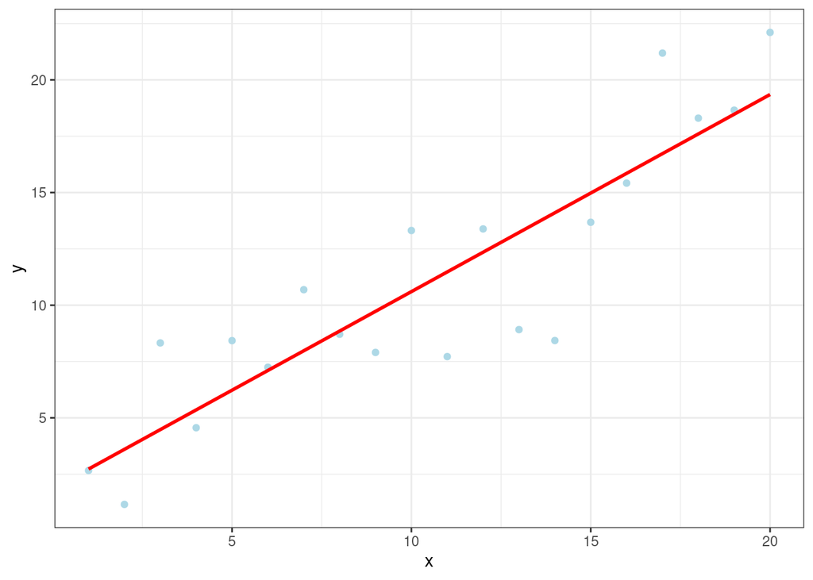

```r
ggplot(data = DFP, aes(x = x, y = y)) +
  geom_point(color = "lightblue") +
  theme_bw() +
  geom_smooth(method = "lm", se = FALSE, color = "red")
```

```r
summary(mod)
```

```
Call:
lm(formula = y ~ x, data = DFP)

Residuals:
    Min      1Q  Median      3Q     Max
-5.6706 -1.4288  0.0384  2.3267  4.4622

Coefficients:
            Estimate Std. Error t value Pr(>|t|)
(Intercept)   1.8543     1.2961   1.431     0.17
x             0.8749     0.1082   8.086  2.1e-07 ***
---
Signif. codes:  0 '***' 0.001 '**' 0.01 '*' 0.05 '.' 0.1 ' ' 1

Residual standard error: 2.79 on 18 degrees of freedom
Multiple R-squared:  0.7841,    Adjusted R-squared:  0.7721
F-statistic: 65.38 on 1 and 18 DF,  p-value: 2.105e-07
```

```r
coefficients(summary(mod)) -> STUFF
STUFF
```

```
             Estimate Std. Error  t value     Pr(>|t|)
(Intercept) 1.8542783   1.296144 1.430611 1.696731e-01
x           0.8748718   0.108200 8.085691 2.104992e-07
```

```r
b0 <- STUFF[1, 1]
b1 <- STUFF[2, 1]
c(b0, b1)
```

```
[1] 1.8542783 0.8748718
```

```r
coef(mod)
```

```
(Intercept)           x
  1.8542783   0.8748718
```

## 1.4 Using `moderndive` wrapper functions

- `get_regression_table()`
- `get_regression_points()`

```r
library(moderndive)
get_regression_table(mod) -> OUT
OUT
```

```
# A tibble: 2 × 7
  term      estimate std_error statistic p_value lower_ci upper_ci
  <chr>        <dbl>     <dbl>     <dbl>   <dbl>    <dbl>    <dbl>
1 intercept    1.85      1.30       1.43    0.17   -0.869     4.58
2 x            0.875     0.108      8.09    0       0.648     1.10
```

```r
OUT$estimate
```

```
[1] 1.854 0.875
```

```r
get_regression_points(mod)
```

```
# A tibble: 20 × 5
      ID     y     x y_hat residual
   <int> <dbl> <int> <dbl>    <dbl>
 1     1  2.66     1  2.73   -0.066
 2     2  1.16     2  3.60   -2.44
 3     3  8.32     3  4.48    3.85
 4     4  4.56     4  5.35   -0.792
 5     5  8.43     5  6.23    2.20
 6     6  7.25     6  7.10    0.143
 7     7 10.7      7  7.98    2.71
 8     8  8.71     8  8.85   -0.143
 9     9  7.90     9  9.73   -1.82
10    10 13.3     10 10.6     2.71
11    11  7.72    11 11.5    -3.76
12    12 13.4     12 12.4     1.03
13    13  8.92    13 13.2    -4.31
14    14  8.43    14 14.1    -5.67
15    15 13.7     15 15.0    -1.30
16    16 15.4     16 15.9    -0.434
17    17 21.2     17 16.7     4.46
18    18 18.3     18 17.6     0.7
19    19 18.7     19 18.5     0.18
20    20 22.1     20 19.4     2.76
```

## 1.5 Prediction

What does the `mod` predict for an `x` value of 15?

```r
yhat <- b0 + b1*15
yhat
```

```
[1] 14.97736
```

```r
# or
predict(mod, newdata = data.frame(x = 15))
```

```
       1
14.97736
```

```r
#
predict(mod, newdata = data.frame(x = 15), interval = "conf", level = 0.95)
```

```
       fit      lwr      upr
1 14.97736 13.31465 16.64006
```

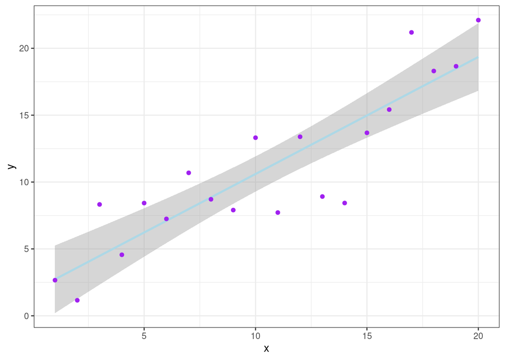

```r
ggplot(data = DFP, aes(x = x, y = y)) +
  theme_bw() +
  geom_smooth(method = "lm", color = "lightblue") +
  geom_point(color = "purple")
```

## 1.6 You try

Use the data set `VIT2005` from the `PASWR2` package to:

1. Create a scatterplot of `totalprice` versus `area`.

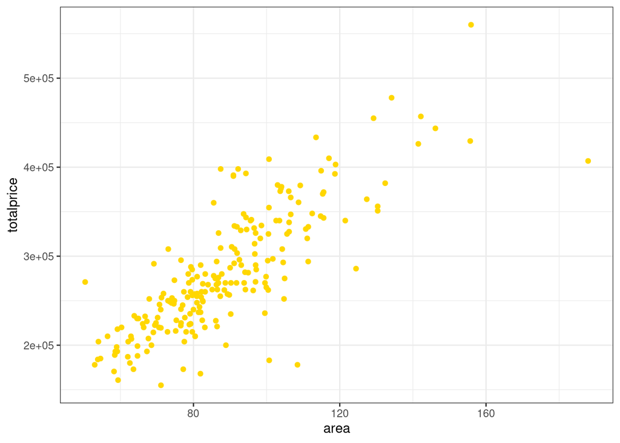

```r
library(PASWR2)
ggplot(data = VIT2005, aes(x = area, y = totalprice)) +
  geom_point(color = "gold") +
  theme_bw() -> p1
p1
```

2. Regress `totalprice` onto `area` and store the resulting model in an object named `mod2`.

```r
# Your code here
mod2 <- lm(totalprice ~ area, data = VIT2005)
summary(mod2)
```

```
Call:
lm(formula = totalprice ~ area, data = VIT2005)

Residuals:
    Min      1Q  Median      3Q     Max
-156126  -21564   -2155   19493  120674

Coefficients:
            Estimate Std. Error t value Pr(>|t|)
(Intercept)  40822.4    12170.1   3.354  0.00094 ***
area          2704.8      133.6  20.243  < 2e-16 ***
---
Signif. codes:  0 '***' 0.001 '**' 0.01 '*' 0.05 '.' 0.1 ' ' 1

Residual standard error: 40810 on 216 degrees of freedom
Multiple R-squared:  0.6548,    Adjusted R-squared:  0.6532
F-statistic: 409.8 on 1 and 216 DF,  p-value: < 2.2e-16
```

3. Add the least squares regression line to the scatterplot created in problem 1.

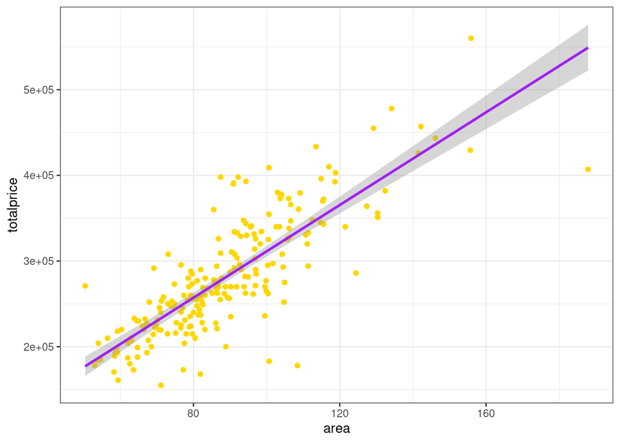

```r
p1 +
  geom_smooth(method = "lm", color = "purple")
```

4. Use `mod2` to predict the price of an apartment that has 100 square meters.

```r
get_regression_table(mod2)
```

```
# A tibble: 2 × 7
  term      estimate std_error statistic p_value lower_ci upper_ci
  <chr>        <dbl>     <dbl>     <dbl>   <dbl>    <dbl>    <dbl>
1 intercept   40822.    12170.      3.35   0.001   16835.   64810.
2 area         2705.      134.     20.2    0        2441.    2968.
```

```r
get_regression_points(mod2, newdata = data.frame(area = 100))
```

```
# A tibble: 1 × 3
     ID  area totalprice_hat
  <int> <dbl>          <dbl>
1     1   100        311298.
```

```r
get_regression_points(mod2, newdata = data.frame(area = 100)) %>%
  pull(totalprice_hat) -> yhat
yhat
```

```
[1] 311297.5
```

```r
predict(mod2, newdata = data.frame(area = 100))
```

```
       1
311297.5
```

```r
predict(mod2, newdata = data.frame(area = 100)) -> yhat2
yhat2
```

```
       1
311297.5
```

```r
#####
coef(mod2)
```

```
(Intercept)        area
  40822.416    2704.751
```

```r
coef(mod2)[1] + coef(mod2)[2]*100 -> yhat3
yhat3
```

```
(Intercept)
   311297.5
```

```r
#####
summary(mod2)$coef
```

```
             Estimate Std. Error   t value     Pr(>|t|)
(Intercept) 40822.416 12170.0915  3.354323 9.395903e-04
area         2704.751   133.6157 20.242761 8.577574e-52
```

```r
summary(mod2)$coef[1, 1] -> b0
summary(mod2)$coef[2, 1] -> b1
yhat4 <- b0 + b1*100
yhat4
```

```
[1] 311297.5
```

```r
c(yhat, yhat2, yhat3, yhat4)
```

```
                      1 (Intercept)
   311297.5    311297.5    311297.5    311297.5
```

5. Interpret the slope for `mod2`.

For every 1 square meter increase in `area`, there is an associated increase of, on average, € 2,705 in `totalprice`.

6. Create a 95% confidence interval for the mean price of apartments with 160 square meters.

```r
predict(mod2, newdata = data.frame(area = 160), interval = "conf", level = 0.95) -> CI
CI
```

```
       fit      lwr      upr
1 473582.6 454031.6 493133.5
```

A 95% confidence interval for $E(Y_h)$ is from € 454,032 to € 493,134.

6. Use the `GRADES` dataframe from the `PASWR2` package to develop a model that predicts GPA based on SAT score. Compute the expected GPA score for an SAT score of 1300.

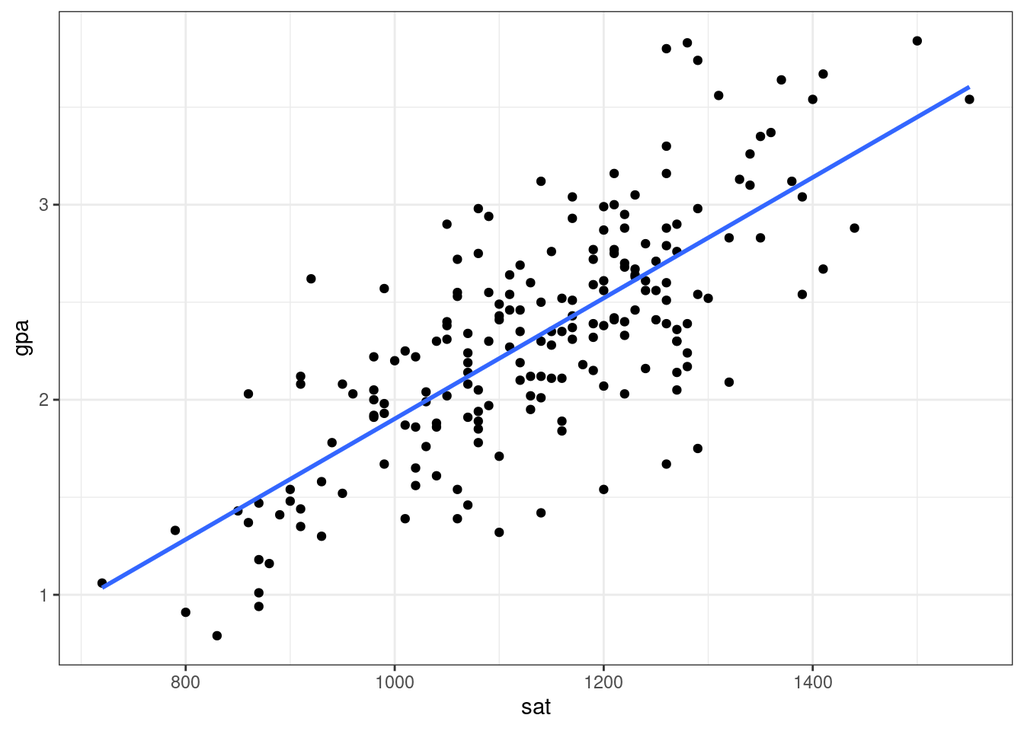

```r
ggplot(data = GRADES, aes(x = sat, y = gpa)) +
  geom_point() +
  theme_bw() +
  geom_smooth(method = "lm", se = FALSE) -> p2
p2
```

```r
mod3 <- lm(gpa ~ sat, data = GRADES)
summary(mod3)
```

```
Call:
lm(formula = gpa ~ sat, data = GRADES)

Residuals:
     Min       1Q   Median       3Q      Max
-1.04954 -0.25960 -0.00655  0.26044  1.09328

Coefficients:
              Estimate Std. Error t value Pr(>|t|)
(Intercept) -1.1920638  0.2224502  -5.359 2.32e-07 ***
sat          0.0030943  0.0001945  15.912  < 2e-16 ***
---
Signif. codes:  0 '***' 0.001 '**' 0.01 '*' 0.05 '.' 0.1 ' ' 1

Residual standard error: 0.3994 on 198 degrees of freedom
Multiple R-squared:  0.5612,    Adjusted R-squared:  0.5589
F-statistic: 253.2 on 1 and 198 DF,  p-value: < 2.2e-16
```

```r
predict(mod3, newdata = data.frame(sat = 1300))
```

```
       1
2.830488
```

```r
library(moderndive)
head(evals)
```

```
# A tibble: 6 × 14
     ID prof_ID score   age bty_avg gender ethni…¹ langu…² rank  pic_o…³ pic_c…⁴
  <int>   <int> <dbl> <int>   <dbl> <fct>  <fct>   <fct>   <fct> <fct>   <fct>
1     1       1   4.7    36       5 female minori… english tenu… not fo… color
2     2       1   4.1    36       5 female minori… english tenu… not fo… color
3     3       1   3.9    36       5 female minori… english tenu… not fo… color
4     4       1   4.8    36       5 female minori… english tenu… not fo… color
5     5       2   4.6    59       3 male   not mi… english tenu… not fo… color
6     6       2   4.3    59       3 male   not mi… english tenu… not fo… color
# … with 3 more variables: cls_did_eval <int>, cls_students <int>,
#   cls_level <fct>, and abbreviated variable names ¹ethnicity, ²language,
#   ³pic_outfit, ⁴pic_color
```

```r
evals %>%
  group_by(rank) %>%
  summarize(Mean = mean(score))
```

```
# A tibble: 3 × 2
  rank          Mean
  <fct>        <dbl>
1 teaching      4.28
2 tenure track  4.15
3 tenured       4.14
```

What are the possible values for $\widehat{score}$ with this model?

```r
modR <- lm(score ~ rank, data = evals)
get_regression_points(modR)
```

```
# A tibble: 463 × 5
      ID score rank         score_hat residual
   <int> <dbl> <fct>            <dbl>    <dbl>
 1     1   4.7 tenure track      4.16    0.545
 2     2   4.1 tenure track      4.16   -0.055
 3     3   3.9 tenure track      4.16   -0.255
 4     4   4.8 tenure track      4.16    0.645
 5     5   4.6 tenured           4.14    0.461
 6     6   4.3 tenured           4.14    0.161
 7     7   2.8 tenured           4.14   -1.34
 8     8   4.1 tenured           4.14   -0.039
 9     9   3.4 tenured           4.14   -0.739
10    10   4.5 tenured           4.14    0.361
# … with 453 more rows
```

```r
get_regression_points(modR) %>%
  select(score_hat) %>%
  unique() %>%
  pull() -> myvalues
myvalues
```

```
[1] 4.155 4.139 4.284
```

The possible values for $\widehat{score}$ are 4.155, 4.139, and 4.284.

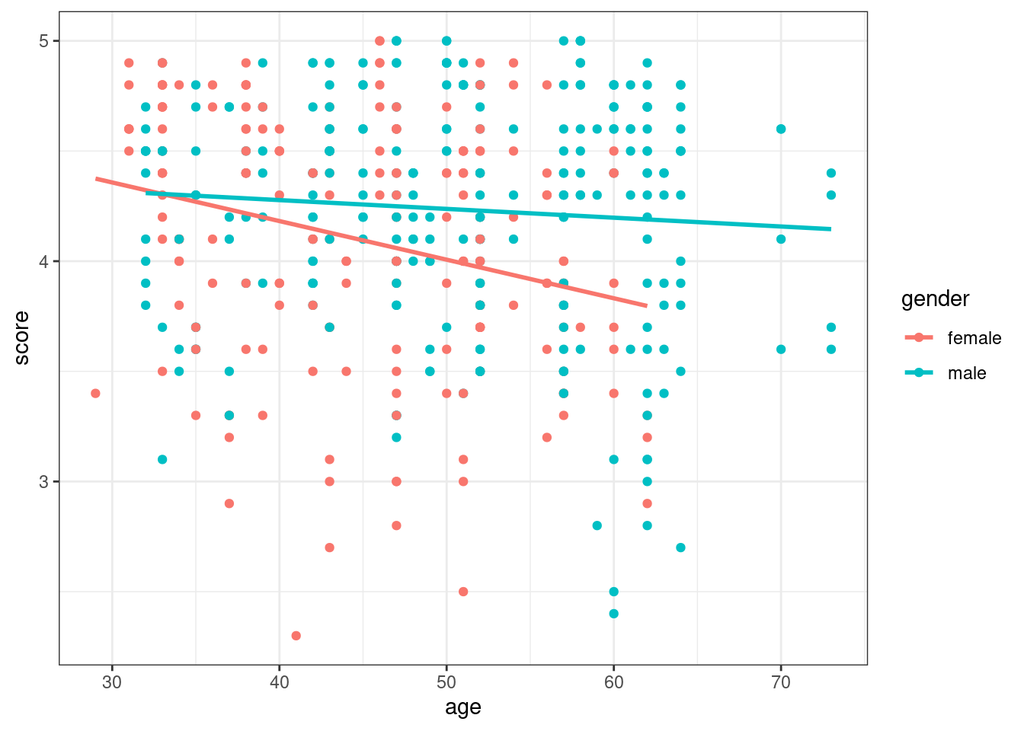

```r
# Interaction Model
ggplot(data = evals, aes(x = age, y = score, color = gender)) +
  geom_point() + theme_bw() +
  geom_smooth(method = "lm", se = FALSE) -> pINT
pINT
```

```r
#
modINT <- lm(score ~ age + gender + age:gender, data = evals)
summary(modINT)
```

```
Call:
lm(formula = score ~ age + gender + age:gender, data = evals)

Residuals:
     Min       1Q   Median       3Q      Max
-1.86453 -0.34815  0.09863  0.40661  0.96327

Coefficients:
                Estimate Std. Error t value Pr(>|t|)
(Intercept)     4.882989   0.205210  23.795  < 2e-16 ***
age            -0.017523   0.004472  -3.919 0.000103 ***
gendermale     -0.446044   0.265407  -1.681 0.093520 .
age:gendermale  0.013531   0.005531   2.446 0.014803 *
---
Signif. codes:  0 '***' 0.001 '**' 0.01 '*' 0.05 '.' 0.1 ' ' 1

Residual standard error: 0.5314 on 459 degrees of freedom
Multiple R-squared:  0.05138,   Adjusted R-squared:  0.04518
F-statistic: 8.288 on 3 and 459 DF,  p-value: 2.227e-05
```

```r
b0M <- coef(modINT)[1] + coef(modINT)[3]
b1M <- coef(modINT)[2] + coef(modINT)[4]
b0F <- coef(modINT)[1]
b1F <- coef(modINT)[2]
c(b0M, b1M, b0F, b1F)
```

```
(Intercept)         age (Intercept)         age
 4.43694553 -0.00399275  4.88298909 -0.01752336
```

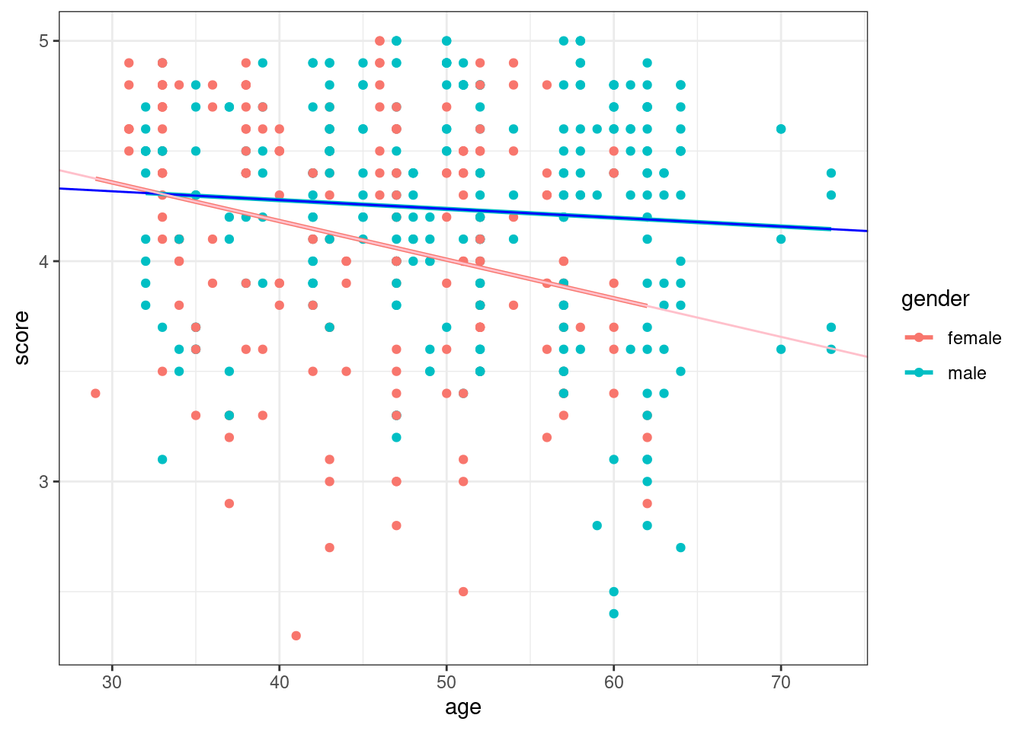

```r
pINT +
  geom_abline(intercept = b0M, slope = b1M, color = "blue") +
  geom_abline(intercept = b0F, slope = b1F, color = "pink")
```

## 1.7 Parallel slopes model

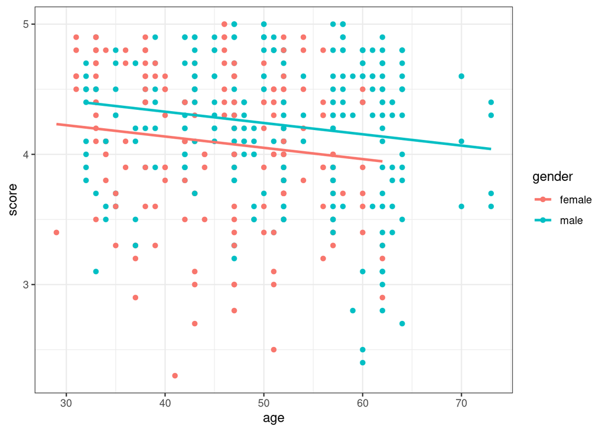

```r
ggplot(data = evals, aes(x = age, y = score, color = gender)) +
  geom_point() +
  geom_parallel_slopes(se = FALSE) +
  theme_bw() -> pPar
pPar
```

```r
modP <- lm(score ~ age + gender, data = evals)
summary(modP)
```

```
Call:
lm(formula = score ~ age + gender, data = evals)

Residuals:
     Min       1Q   Median       3Q      Max
-1.82833 -0.33494  0.09391  0.42882  0.91506

Coefficients:
             Estimate Std. Error t value Pr(>|t|)
(Intercept)  4.484116   0.125284  35.792  < 2e-16 ***
age         -0.008678   0.002646  -3.280 0.001117 **
gendermale   0.190571   0.052469   3.632 0.000313 ***
---
Signif. codes:  0 '***' 0.001 '**' 0.01 '*' 0.05 '.' 0.1 ' ' 1

Residual standard error: 0.5343 on 460 degrees of freedom
Multiple R-squared:  0.03901,   Adjusted R-squared:  0.03484
F-statistic: 9.338 on 2 and 460 DF,  p-value: 0.0001059
```

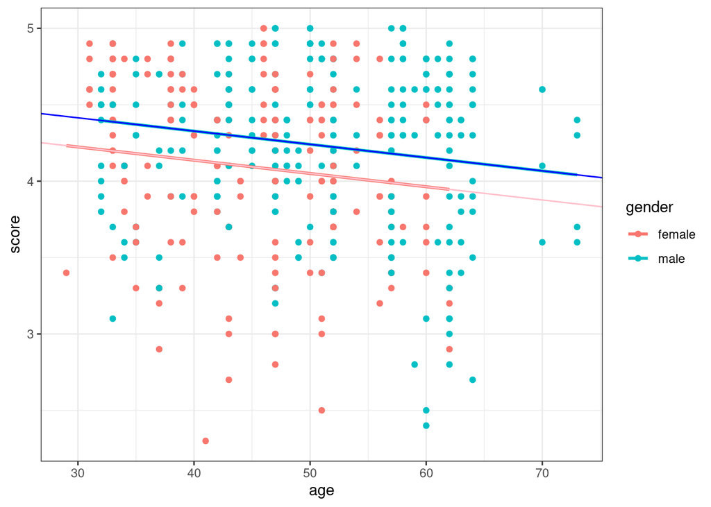

```r
b0M <- coef(modP)[1] + coef(modP)[3]
b0F <- coef(modP)[1]
b1M <- coef(modP)[2]
b1F <- coef(modP)[2]
#
pPar +
  geom_abline(intercept = b0M, slope = b1M, color = "blue") +
  geom_abline(intercept = b0F, slope = b1F, color = "pink")
```

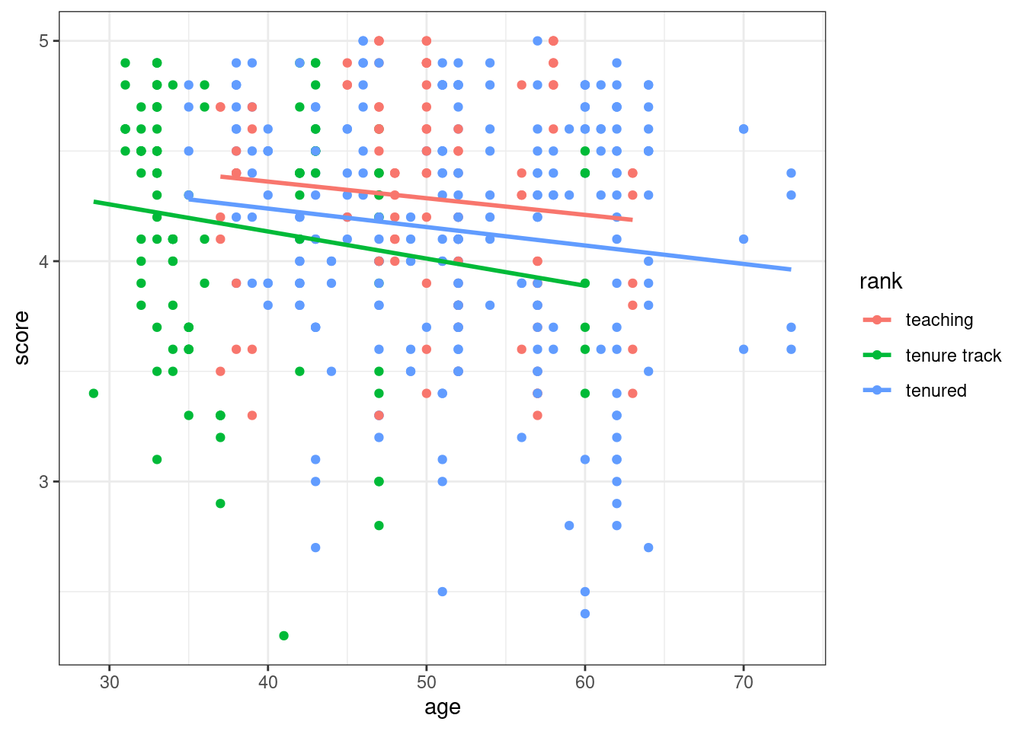

```r
# Interaction Model
ggplot(data = evals, aes(x = age, y = score, color = rank)) +
  geom_point() +
  geom_smooth(method = "lm", se = FALSE) +
  theme_bw()
```

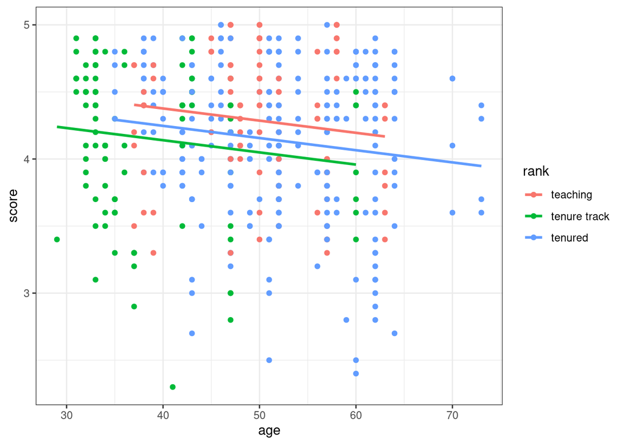

```r
# Parallel Slopes Model
ggplot(data = evals, aes(x = age, y = score, color = rank)) +
  geom_point() +
  geom_parallel_slopes(se = FALSE) +
  theme_bw()
```

## 1.8 Two approaches

```r
evals %>%
  group_by(pic_color) %>%
  summarize(M = mean(score))
```

```
# A tibble: 2 × 2
  pic_color       M
  <fct>       <dbl>
1 black&white  4.36
2 color        4.14
```

```r
#
modCP <- lm(score ~ pic_color, data = evals)
summary(modCP)
```

```
Call:
lm(formula = score ~ pic_color, data = evals)

Residuals:
    Min      1Q  Median      3Q     Max
-1.8369 -0.3615  0.1385  0.4385  0.8631

Coefficients:
               Estimate Std. Error t value Pr(>|t|)
(Intercept)     4.36154    0.06090  71.613  < 2e-16 ***
pic_colorcolor -0.22466    0.06679  -3.364 0.000833 ***
---
Signif. codes:  0 '***' 0.001 '**' 0.01 '*' 0.05 '.' 0.1 ' ' 1

Residual standard error: 0.5379 on 461 degrees of freedom
Multiple R-squared:  0.02395,   Adjusted R-squared:  0.02184
F-statistic: 11.31 on 1 and 461 DF,  p-value: 0.0008334
```

```r
MBW <- coef(modCP)[1]
MCP <- coef(modCP)[1] + coef(modCP)[2]
c(MBW, MCP)
```

```
(Intercept) (Intercept)
   4.361538    4.136883
```

## 1.9 Your Turn:

Create a scatterplot of `score` versus `bty_avg` while mapping `gender` to color. Would you use an interaction model or a parallel slopes model? Add the appropriate model to your scatterplot. Write the equations for the two lines in your scatterplot.

```r
mod4 <- lm(score ~ bty_avg + gender, data = evals)
mod5 <- lm(score ~ bty_avg + gender + bty_avg:gender, data = evals)
summary(mod4)
```

```
Call:
lm(formula = score ~ bty_avg + gender, data = evals)

Residuals:
    Min      1Q  Median      3Q     Max
-1.8305 -0.3625  0.1055  0.4213  0.9314

Coefficients:
            Estimate Std. Error t value Pr(>|t|)
(Intercept)  3.74734    0.08466  44.266  < 2e-16 ***
bty_avg      0.07416    0.01625   4.563 6.48e-06 ***
gendermale   0.17239    0.05022   3.433 0.000652 ***
---
Signif. codes:  0 '***' 0.001 '**' 0.01 '*' 0.05 '.' 0.1 ' ' 1

Residual standard error: 0.5287 on 460 degrees of freedom
Multiple R-squared:  0.05912,   Adjusted R-squared:  0.05503
F-statistic: 14.45 on 2 and 460 DF,  p-value: 8.177e-07
```

```r
summary(mod5)
```

```
Call:
lm(formula = score ~ bty_avg + gender + bty_avg:gender, data = evals)

Residuals:
    Min      1Q  Median      3Q     Max
-1.8084 -0.3828  0.0903  0.4037  0.9211

Coefficients:
                   Estimate Std. Error t value Pr(>|t|)
(Intercept)         3.95006    0.11800  33.475   <2e-16 ***
bty_avg             0.03064    0.02400   1.277   0.2024
gendermale         -0.18351    0.15349  -1.196   0.2325
bty_avg:gendermale  0.07962    0.03247   2.452   0.0146 *
---
Signif. codes:  0 '***' 0.001 '**' 0.01 '*' 0.05 '.' 0.1 ' ' 1

Residual standard error: 0.5258 on 459 degrees of freedom
Multiple R-squared:  0.07129,   Adjusted R-squared:  0.06522
F-statistic: 11.74 on 3 and 459 DF,  p-value: 1.997e-07
```

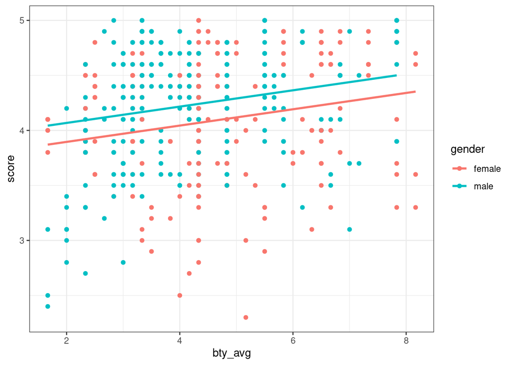

```r
ggplot(data = evals, aes(x = bty_avg, y= score, color = gender)) +
  geom_point() +
  geom_parallel_slopes(se = FALSE) +
  theme_bw()
```

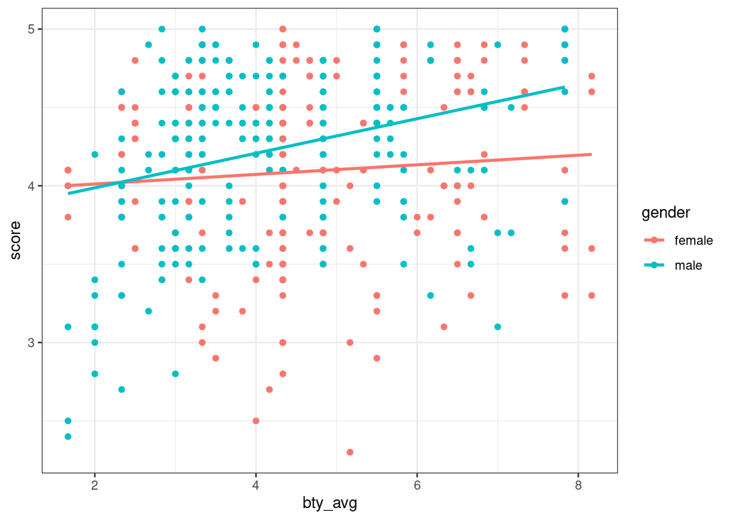

```r
ggplot(data = evals, aes(x = bty_avg, y= score, color = gender)) +
  geom_point() +
  geom_smooth(method = "lm", se = FALSE) +
  theme_bw()
```